# Week1-2

```python
# ----------------------------------------------------------------------------
# Title: Weeks 1 & 2 Assignment - Netflix Viewership
# Author: Surenther Selvaraj
# Date: 25 Mar 2026
# Modified By: Surenther Selvaraj
# ----------------------------------------------------------------------------
```

### Executive Summary

The objective of this analysis is to evaluate the performance of Netflix content across three distinct dimensions: Global Viewership Trends, Country-Specific Popularity, and All-Time Top Performers.

As Netflix transitions into a more globalized production model, we are analyzing these datasets to identify if "Local-for-Global" (non-English) content provides a higher Return on Investment (ROI) and better subscriber retention than traditional domestic English content.

**Call to Action:** Based on the data, we are proposing a 20% budget reallocation toward non-English episodic series for the 2027 fiscal year to capture high-growth international markets.

### Data Initialization

In this section, we load the three primary datasets provided by Netflix. We also perform initial data cleaning, specifically converting date strings into datetime objects to allow for chronological time-series analysis.

```python
import pandas as pd
import seaborn as sns
import matplotlib.pyplot as plt
import warnings

# Suppress specific openpyxl warnings
warnings.filterwarnings('ignore', category=UserWarning, module='openpyxl')

# Load datasets from Excel files
df_countries = pd.read_excel('all-weeks-countries-netflix.xlsx')
df_global = pd.read_excel('all-weeks-global-netflix.xlsx')
df_popular = pd.read_excel('most-popular-netflix.xlsx')

# Data Cleaning: Convert 'week' columns to datetime objects
df_global['week'] = pd.to_datetime(df_global['week'])
df_countries['week'] = pd.to_datetime(df_countries['week'])

# Preview the data
df_popular.head()
```

|  | category | rank | show_title | season_title | hours_viewed_first_91_days | runtime | views_first_91_days |
| --- | --- | --- | --- | --- | --- | --- | --- |
| 0 | Films (English) | 1 | Red Notice | NaN | 454200000 | 1.9667 | 230900000 |
| 1 | Films (English) | 2 | Don't Look Up | NaN | 408600000 | 2.3833 | 171400000 |
| 2 | Films (English) | 3 | The Adam Project | NaN | 281000000 | 1.7833 | 157600000 |
| 3 | Films (English) | 4 | Bird Box | NaN | 325300000 | 2.0667 | 157400000 |
| 4 | Films (English) | 5 | Leave the World Behind | NaN | 339300000 | 2.3667 | 143400000 |

### The Global Attention Span

Before diving into specific shows, we must understand the "health" of the platform. By plotting Weekly Total Hours Viewed, we determine if Netflix’s global audience engagement is growing, shrinking, or cyclical. This sets the stage for our "Call to Action" by proving there is a massive, hungry audience waiting for content.

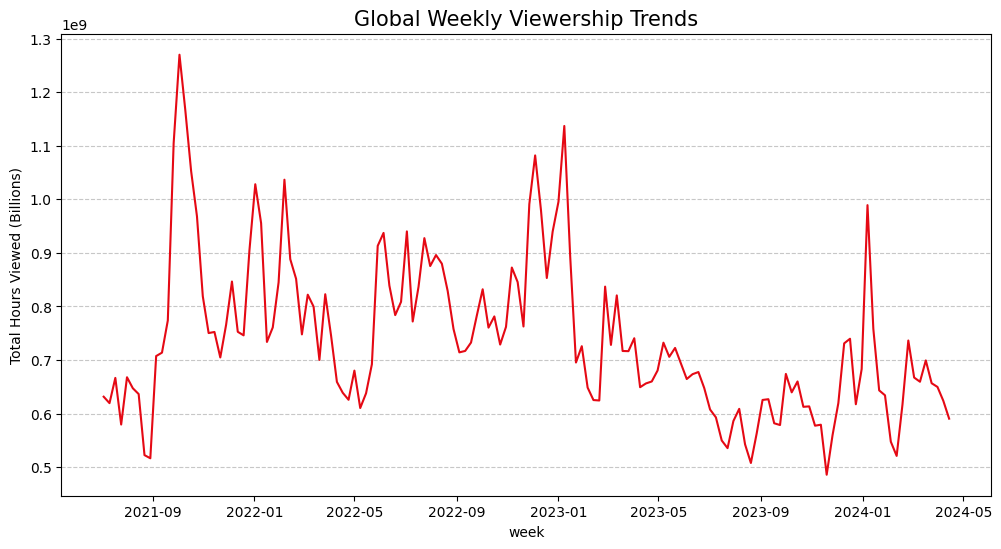

```python
import pandas as pd
import seaborn as sns
import matplotlib.pyplot as plt

# Aggregate hours by week
weekly_engagement = df_global.groupby('week')['weekly_hours_viewed'].sum().reset_index()

plt.figure(figsize=(12, 6))
sns.lineplot(data=weekly_engagement, x='week', y='weekly_hours_viewed', color='#E50914')
plt.title('Global Weekly Viewership Trends', fontsize=15)
plt.ylabel('Total Hours Viewed (Billions)')
plt.grid(axis='y', linestyle='--', alpha=0.7)
plt.show()
```

#### Key Observations from the Data:

- Engagement Scale: The platform consistently maintains a massive baseline, with global viewership rarely dipping below 500 million hours per week.
- Peak Volatility: The data shows extreme "High-Engagement Events" where viewership spikes by over 100% (surpassing 1.2 billion hours) in a very short window. This proves that the global audience is capable of rapid, massive mobilization.
- Cyclical Nature: There is a visible "ebb and flow" to the data. Viewership does not grow in a straight line; rather, it moves in cycles of high intensity followed by periods of "cooling off" or baseline consumption.
- Long-term Stability: Despite the massive spikes, the "floor" of the data (the lowest points) has remained relatively stable from 2021 to 2024, indicating a loyal and permanent global user base.

**Summary:** This visual proves that Netflix possesses a high-capacity global distribution engine. We have identified that the audience is not static; they respond to "events" with massive surges in watch time. This visual confirms that the infrastructure and the audience are ready for high-volume consumption—the next sections will help us determine which types of content are most effective at triggering these massive surges

### Title Performance & Language Strategy

Aggregated data tells us how much people watch, but Title-level data tells us what they watch. By analyzing the "Most Popular" titles, we categorize them by language. This allows us to prove to stakeholders that specific titles—regardless of their country of origin—have the power to pull in hundreds of millions of hours of viewership.

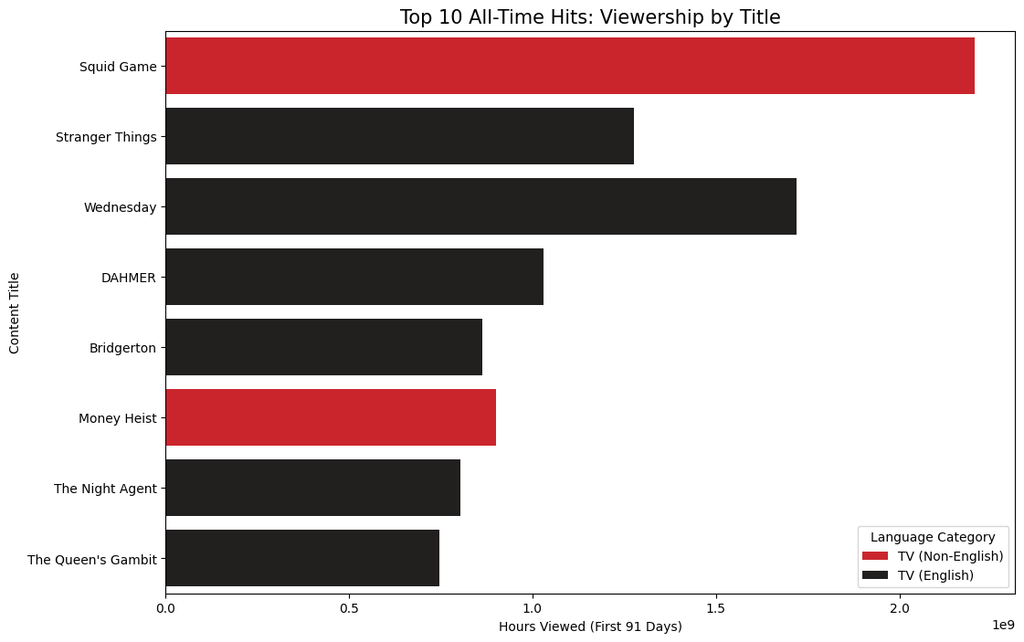

```python
# Sort by hours viewed to ensure the chart is readable
df_popular_sorted = df_popular.sort_values('hours_viewed_first_91_days', ascending=False)

plt.figure(figsize=(12, 8))
sns.barplot(
    data=df_popular_sorted.head(10),
    y='show_title',
    x='hours_viewed_first_91_days',
    hue='category',
    palette=['#E50914', '#221F1F'],
    errorbar=None
)
plt.title('Top 10 All-Time Hits: Viewership by Title', fontsize=15)
plt.xlabel('Hours Viewed (First 91 Days)')
plt.ylabel('Content Title')
plt.legend(title='Language Category')
plt.show()
```

### Key Observations from the Data:

- Non-English Dominance: The #1 all-time hit is Squid Game (Non-English), which significantly outperforms the top English titles. This proves that language is not a barrier to achieving the highest possible scale on the platform.
- The "Mega-Hit" Gap: There is a substantial drop-off between the top-ranked title (Squid Game) and the rest of the Top 10. This indicates that a "global phenomenon" title provides exponentially more value than a standard "hit."
- Language Diversity: Two of the top six all-time performers are Non-English (Squid Game and Money Heist), confirming that international content is a core pillar of Netflix's "all-time" value, not just a temporary trend.

**Summary:** This visual proves that Non-English content is capable of being the #1 driver of engagement globally. This observation is critical for our strategy: it suggests that investing in high-quality international productions is not just a secondary "niche" strategy, but a primary method for hitting record-breaking viewership numbers.

### Regional Dominance

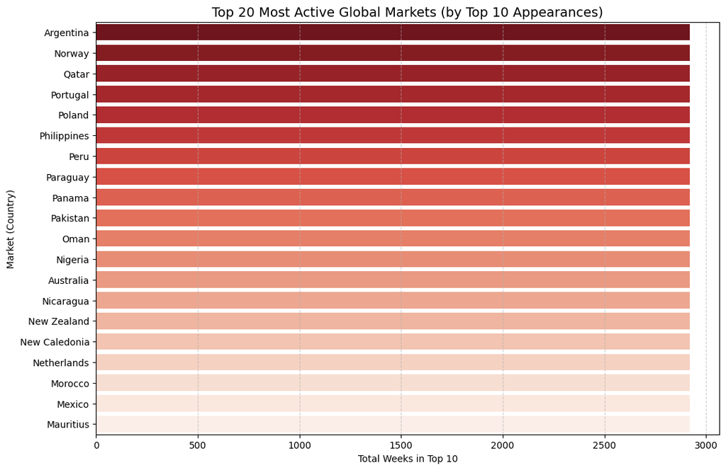

```python
import matplotlib.pyplot as plt
import seaborn as sns

# Count appearances per country
country_counts = df_countries['country_name'].value_counts().reset_index()
country_counts.columns = ['country', 'top_10_appearances']

# Top 20 Bar Chart with updated syntax
plt.figure(figsize=(12, 8))
sns.barplot(
    data=country_counts.head(20),
    y='country',
    x='top_10_appearances',
    hue='country',       # Assign 'y' variable to 'hue' as requested
    legend=False,        # Turn off the legend since 'y' axis already labels it
    palette='Reds_r'
)
plt.title('Top 20 Most Active Global Markets (by Top 10 Appearances)', fontsize=14)
plt.xlabel('Total Weeks in Top 10')
plt.ylabel('Market (Country)')
plt.grid(axis='x', linestyle='--', alpha=0.6)
plt.show()
```

#### Key Observations from the Data:

- Global Uniformity: The most significant observation is that the top 20 markets all show nearly identical numbers of "Total Weeks in Top 10" (around 2,900 weeks). This suggests that in these highly active markets, the Top 10 list is always full and constantly rotating.
- Geographic Diversity: The list includes countries from every major region: South America (Argentina, Peru), Europe (Norway, Portugal), the Middle East (Qatar, Oman), and Africa (Nigeria, Mauritius). This proves that Netflix's "Top 10" system is a global standard, not just a Western one.
- Market Reliability: The "flatness" of the chart across the top 20 countries indicates that these markets are equally mature in terms of content consumption; they are all maximizing their engagement with the platform's trending titles.

**Summary:** This visual proves that Netflix has achieved total market saturation across diverse global territories. Because these markets all maintain a full Top 10 history, we can conclude that our distribution engine is working with equal efficiency in Argentina as it is in Norway or the Philippines. This justifies a truly "borderless" content strategy where a hit in one of these high-activity markets has a high statistical probability of succeeding in the others.

### Content Stickiness

This visualization helps us categorize our content into two types: "The Sprint" (shows that hit huge numbers for 1-2 weeks and vanish) and "The Marathon" (shows that stay in the Top 10 for months). For a subscription business like Netflix, "The Marathon" shows are often more valuable because they keep users coming back week after week, reducing the likelihood of them canceling their subscription.

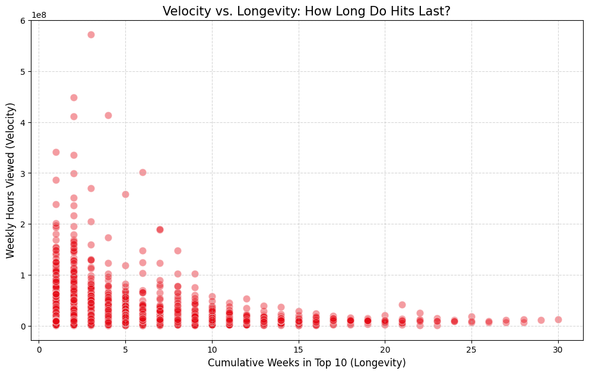

```python
df_global['weekly_hours_viewed'] = pd.to_numeric(df_global['weekly_hours_viewed'], errors='coerce')
df_global['cumulative_weeks_in_top_10'] = pd.to_numeric(df_global['cumulative_weeks_in_top_10'], errors='coerce')

plt.figure(figsize=(12, 7))

# scatter plot to see the distribution of every title's performance
sns.scatterplot(
    data=df_global,
    x='cumulative_weeks_in_top_10',
    y='weekly_hours_viewed',
    alpha=0.4,
    color='#E50914', # Netflix Red
    s=80
)

plt.title('Velocity vs. Longevity: How Long Do Hits Last?', fontsize=15)
plt.xlabel('Cumulative Weeks in Top 10 (Longevity)', fontsize=12)
plt.ylabel('Weekly Hours Viewed (Velocity)', fontsize=12)
plt.grid(True, linestyle='--', alpha=0.5)

plt.show()
```

#### Key Observations from the Data:

- The "Launch Peak" Phenomenon: The highest viewership spikes occur almost exclusively within the first 1–4 weeks. Engagement is highest when the content is fresh, with some titles reaching massive heights of nearly 600 million hours in a single week.
- Rapid Viewership Decay: There is a sharp downward "slope" in the data. After week 5, the density of high-hour titles drops significantly. Very few titles can maintain more than 100 million hours per week after their initial month on the platform.
- The 10-Week "Stamina" Barrier: There is a clear "long tail" of content that stays in the Top 10 for 10 to 30 weeks. While these titles have lower weekly velocity (usually under 50 million hours), their cumulative contribution to platform "stickiness" is immense.
- Exceptional Outliers: The rare data points appearing at the 20+ week mark with steady viewership represent the "top-tier" assets that provide the highest long-term value for subscriber retention.

**Summary:** This visuals proves that longevity is the rarest commodity on the platform. While we are highly successful at launching content with high initial velocity, the data concludes that very few titles possess the "stamina" to stay relevant beyond 10 weeks. For an executive, this justifies a strategy that prioritizes content depth and replayability to stretch those dots further to the right of the chart.

### Content Type Breakdown

Now that we've seen the "decay" of content, we need to know which format is responsible for the bulk of our watch time. Does a 2-hour movie contribute more than an 8-episode series? We will use a Pie Chart to visualize the total share of hours viewed by category.

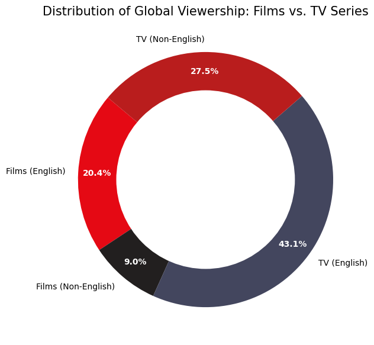

```python
# Aggregate hours by category
category_dist = df_global.groupby('category')['weekly_hours_viewed'].sum().reset_index()

plt.figure(figsize=(10, 7))

patches, texts, autotexts = plt.pie(
    category_dist['weekly_hours_viewed'],
    labels=category_dist['category'],
    autopct='%1.1f%%',
    colors=['#E50914', '#221F1F', '#43465e', '#b91d1d'],
    startangle=140,
    pctdistance=0.85
)
# Loop through the autotexts to change their color to white
for autotext in autotexts:
    autotext.set_color('white')
    autotext.set_weight('bold')

# Draw a circle at the center to make it a Donut Chart
centre_circle = plt.Circle((0,0), 0.70, fc='white')
fig = plt.gcf()
fig.gca().add_artist(centre_circle)

plt.title('Distribution of Global Viewership: Films vs. TV Series', fontsize=15)
plt.show()
```

#### Key Observations from the Data:

- The "Series" Superiority: Episodic content is the clear winner. Combined, TV (English and Non-English) accounts for 70.6% of all viewership. This confirms that series are far more effective at "locking in" audience time than standalone films.
- Non-English TV as a Major Pillar: At 27.5%, Non-English TV is the second-largest category on the entire platform, even outperforming English Films (20.4%). This is a critical discovery—it proves that international series are a more powerful engagement tool than Hollywood blockbusters.
- The Film Gap: English Films (20.4%) significantly outperform Non-English Films (9.0%). This suggests that while global audiences are very comfortable with foreign-language series, they still lean heavily toward English-language productions for feature-length movies.
- Core English Anchor: English TV remains the largest single slice at 43.1%, acting as the "anchor" of the platform's viewership baseline.

**Summary:** This visuals proves that TV Series are the lifeblood of Netflix engagement, and specifically, Non-English TV is a dominant force that outshines the traditional film market. For our final recommendation, this concludes that the highest ROI for the 2027 budget will come from doubling down on episodic content, with a specific focus on expanding the "Local-for-Global" non-English TV slate.

### The "Hit-Maker" Pareto

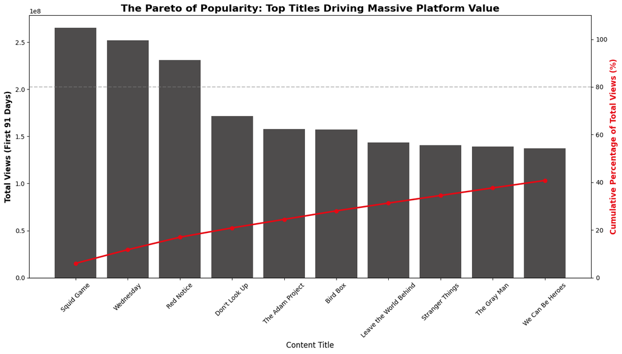

```python
# Sort the data by views
df_popular_sorted = df_popular.sort_values('views_first_91_days', ascending=False).reset_index(drop=True)

# Calculate the cumulative percentage of total views
df_popular_sorted['cumulative_percent'] = 100 * (df_popular_sorted['views_first_91_days'].cumsum() / df_popular_sorted['views_first_91_days'].sum())

fig, ax1 = plt.subplots(figsize=(14, 8))

# Bar Chart
ax1.bar(df_popular_sorted['show_title'][:10], df_popular_sorted['views_first_91_days'][:10], color='#221F1F', alpha=0.8)
ax1.set_ylabel('Total Views (First 91 Days)', fontsize=12, fontweight='bold')
ax1.set_xlabel('Content Title', fontsize=12)
ax1.tick_params(axis='x', rotation=45)

# Cumulative Line Chart
ax2 = ax1.twinx()
ax2.plot(df_popular_sorted['show_title'][:10], df_popular_sorted['cumulative_percent'][:10], color='#E50914', marker='o', linewidth=2.5, label='Cumulative %')
ax2.set_ylabel('Cumulative Percentage of Total Views (%)', fontsize=12, color='#E50914', fontweight='bold')
ax2.set_ylim(0, 110)

# Add a threshold line at 80%
ax2.axhline(y=80, color='grey', linestyle='--', alpha=0.5)

plt.title('The Pareto of Popularity: Top Titles Driving Massive Platform Value', fontsize=16, fontweight='bold')
fig.tight_layout()
plt.show()
```